# Анализы по проекту MyTrEd

## Анализ роста и индекса состояния в зависимости от биотического окружения

| term | estimate | std.error | statistic | p.value |
| --- | --- | --- | --- | --- |
| (Intercept) | 2.4142232 | 0.1210720 | 19.940391 | 0.0000000 |
| PropT | -0.4507067 | 0.1801726 | -2.501528 | 0.0127936 |
| Morphotypet | -0.6004976 | 0.1377146 | -4.360451 | 0.0000168 |
| ExperimentWinter | -0.8664934 | 0.1346298 | -6.436117 | 0.0000000 |
| N_total | -0.0154733 | 0.0010476 | -14.769835 | 0.0000000 |
| PropT:Morphotypet | 0.6721240 | 0.2772858 | 2.423940 | 0.0158279 |
| PropT:ExperimentWinter | 0.7565452 | 0.2690591 | 2.811818 | 0.0051865 |
| Morphotypet:ExperimentWinter | 0.4560356 | 0.2053544 | 2.220725 | 0.0269697 |
| PropT:Morphotypet:ExperimentWinter | -0.4002854 | 0.3997951 | -1.001227 | 0.3173664 |

Это финальная модель, описывающая связь DL со всеми предикторами. Ее формула следующая

Model: log(DL + 1) ~ PropT + Morphotype + Experiment + N_total + PropT:Morphotype + PropT:Experiment + Morphotype:Experiment + PropT:Morphotype:Experiment

Вот визуализация этой модели

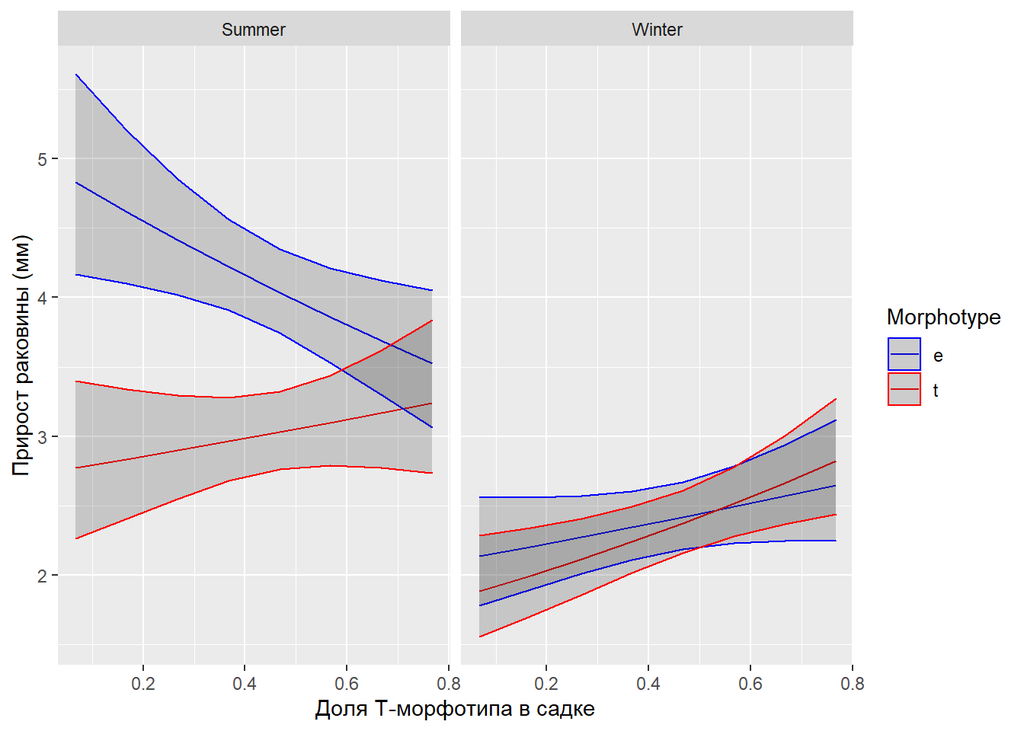

Ну и сильное влияние, конечно, оказывает плотность поселения. Чем выше плотность, тем ниже прирост (см. таблицу с коэффициентами модели)

| Morphotype | Experiment | PropT.trend | std.error | df | statistic | p.value |
| --- | --- | --- | --- | --- | --- | --- |
| e | Summer | -0.4507067 | 0.1801726 | 373 | -2.5015280 | 0.0127936 |
| t | Summer | 0.2214173 | 0.2360578 | 373 | 0.9379792 | 0.3488620 |
| e | Winter | 0.3058385 | 0.2045142 | 373 | 1.4954388 | 0.1356455 |
| t | Winter | 0.5776772 | 0.2047774 | 373 | 2.8210002 | 0.0050434 |

Получается, что в летнем эксперименте мы уловили замедление роста E-морфотипа по мере увеличения PropT, то есть в условиях доминирования T-морфотипа. В зимнем эксперименте мы уловили замедление роста T-морфотипа в условиях доминирования E.

### Теперь про CI.

Вот такая финальная модель получилась.

СI ~ PropT + Morphotype + Experiment + N_total + PropT:Morphotype + PropT:Experiment + Morphotype:Experiment + PropT:Morphotype:Experiment

Здесь нельзя избежать случайного эффекта садка (ICC довольно высоки) так что добавлен random = ~1 | Cage_ID.

| effect | group | term | estimate | std.error | df | statistic | p.value |
| --- | --- | --- | --- | --- | --- | --- | --- |
| fixed | fixed | (Intercept) | 0.1645703 | 0.0084302 | 338 | 19.5214165 | 0.0000000 |
| fixed | fixed | PropT | -0.0296098 | 0.0121883 | 26 | -2.4293571 | 0.0223394 |
| fixed | fixed | Morphotypet | 0.0032243 | 0.0067063 | 338 | 0.4807836 | 0.6309813 |
| fixed | fixed | ExperimentWinter | -0.0483702 | 0.0084828 | 26 | -5.7021309 | 0.0000053 |
| fixed | fixed | N_total | -0.0008169 | 0.0000752 | 26 | -10.8601050 | 0.0000000 |
| fixed | fixed | PropT:Morphotypet | 0.0335415 | 0.0134522 | 338 | 2.4933860 | 0.0131308 |
| fixed | fixed | PropT:ExperimentWinter | 0.0342030 | 0.0168454 | 26 | 2.0304056 | 0.0526609 |
| fixed | fixed | Morphotypet:ExperimentWinter | 0.0213758 | 0.0099587 | 338 | 2.1464310 | 0.0325500 |
| fixed | fixed | PropT:Morphotypet:ExperimentWinter | -0.0386434 | 0.0194039 | 338 | -1.9915252 | 0.0472276 |
| ran_pars | Cage_ID | sd_(Intercept) | 0.0064885 | NA | NA | NA | NA |
| ran_pars | Residual | sd_Observation | 0.0207729 | NA | NA | NA | NA |

Вот визуализация этой модели

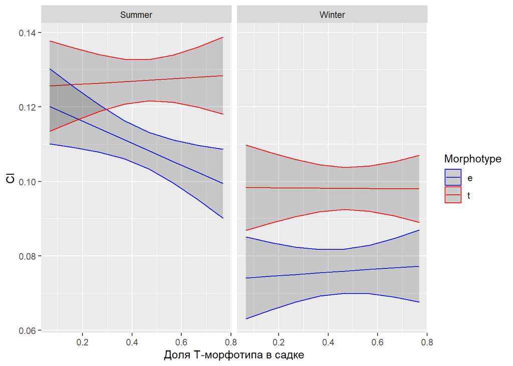

Вот оценки частных угловых коэффициентов

| Morphotype | Experiment | PropT.trend | std.error | df | statistic | p.value |
| --- | --- | --- | --- | --- | --- | --- |
| e | Summer | -0.0296098 | 0.0121883 | 26 | -2.4293571 | 0.0223394 |
| t | Summer | 0.0039317 | 0.0142218 | 26 | 0.2764563 | 0.7843834 |
| e | Winter | 0.0045933 | 0.0122842 | 26 | 0.3739158 | 0.7114989 |
| t | Winter | -0.0005087 | 0.0123441 | 26 | -0.0412106 | 0.9674428 |

В летнем эксперименте показано, что у E-морфотипа СI снижается если в садках доминируют T-морфотипы.

## Анализ смертности

Здесь изучаем как изменяется доля погибших от общей численности особей данного морфотипа в зависимости от предикторов. Нас интересует связь c PropT. Однако общая численность живых тоже вставлена в качестве ковариаты. Во формула модели

P_dead_morph ~ PropT * Dead_morph * Experiment + N_total

Вот параметры модели. Зависимость смоделирована с помощью бета-регрессии, поэтому там еще параметр фи появился.

| component | term | estimate | std.error | statistic | p.value |
| --- | --- | --- | --- | --- | --- |
| mean | (Intercept) | -3.2652263 | 0.6330219 | -5.1581570 | 0.0000002 |
| mean | PropT | 2.4861737 | 0.9358340 | 2.6566397 | 0.0078924 |
| mean | Dead_morphdead_E | -1.3231669 | 0.6587771 | -2.0085198 | 0.0445881 |
| mean | ExperimentWinter | 1.0491976 | 0.6365825 | 1.6481721 | 0.0993174 |
| mean | N_total | 0.0273372 | 0.0053011 | 5.1568810 | 0.0000003 |
| mean | PropT:Dead_morphdead_E | -0.8769067 | 1.3645884 | -0.6426162 | 0.5204731 |
| mean | PropT:ExperimentWinter | -3.7581187 | 1.2791751 | -2.9379236 | 0.0033042 |
| mean | Dead_morphdead_E:ExperimentWinter | 1.8991257 | 0.9106509 | 2.0854596 | 0.0370276 |
| mean | PropT:Dead_morphdead_E:ExperimentWinter | 1.0395595 | 1.8365614 | 0.5660358 | 0.5713695 |
| precision | (phi) | 6.4717835 | 1.1763503 | 5.5015784 | 0.0000000 |

Вот визуализация модели.

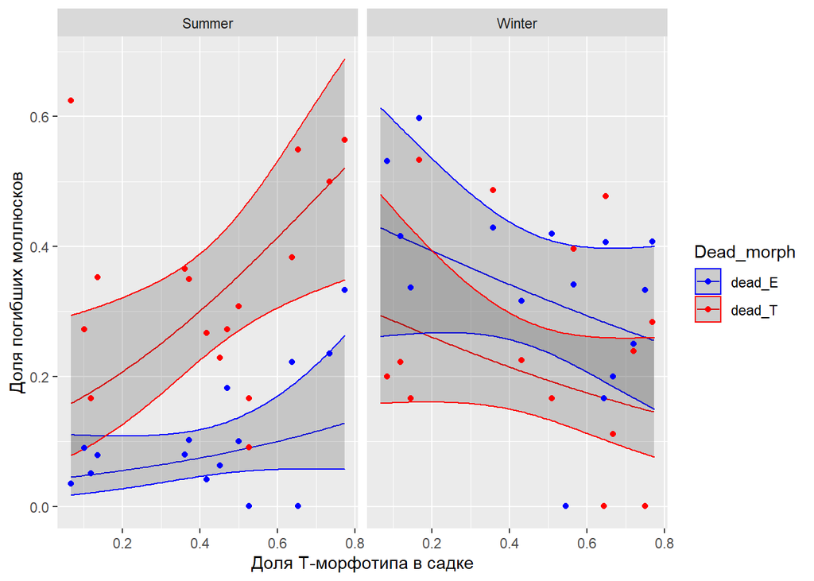

Значимо отличается от нуля только частный угловой коэффициент для Т-морфотипа в Летнем эксперименте.

| Dead_morph | Experiment | PropT.trend | std.error | df | z.ratio | p.value |
| --- | --- | --- | --- | --- | --- | --- |
| dead_T | Summer | 0.5480592 | 0.2102069 | Inf | 2.607236 | 0.0091276 |
| dead_E | Summer | 0.1191430 | 0.0881942 | Inf | 1.350917 | 0.1767221 |
| dead_T | Winter | -0.2065233 | 0.1481322 | Inf | -1.394182 | 0.1632625 |
| dead_E | Winter | -0.2449148 | 0.1876139 | Inf | -1.305419 | 0.1917501 |

NB! Возможно анализ смертности для зимнего эксперимента не очень адекватен. Там много раковин развалилось в труху.

## Анализ силы прикрепления в зависимости от биотического окружения

Модель была вот такая.

log(True_Force+1) ~ Morphotype*PropT + N_total + Fin_size

Вот параметры модели.

| term | estimate | std.error | statistic | p.value |
| --- | --- | --- | --- | --- |
| (Intercept) | -0.1718948 | 0.3051699 | -0.5632758 | 0.5741746 |
| Morphotypet | 0.1508639 | 0.0991261 | 1.5219386 | 0.1303462 |
| PropT | -0.0502775 | 0.1296017 | -0.3879382 | 0.6986683 |
| N_total | -0.0043276 | 0.0012050 | -3.5912704 | 0.0004586 |
| Fin_size | 0.0302435 | 0.0100003 | 3.0242527 | 0.0029805 |
| Morphotypet:PropT | 0.1262737 | 0.1853376 | 0.6813173 | 0.4968292 |

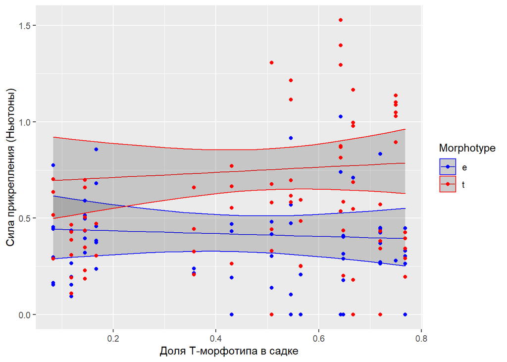

Можно обратить внимание на то, что при малом значении PropT доверительные интервалы перекрываются, а при высоких значениях нет. То есть в условиях доминирования T-морфотипа T крепятся сильнее, чем E. Однако в условиях доминирования E-морфотипа различия в силе прикрепления не столь выражены.

## Анализ открытости-закрытости раковин мидий в процессе циклического изменения солености

Здесь я еще не все доделал. Но визуализация более или менее вот такая. Моделируется вероятность быть открыой. Вместо солености как таковой здесь по оси ОХ отложен номер измерения солености в цикле (в середине самая низкая соленость). Обрати внимание, что с увеличением количества циклов они все более и более открытые.

```
## [1] "Exp1" "Exp2" "Exp3"
```

```
##
##  Maximum number of PQL iterations:  20
```

```
##
##  Maximum number of PQL iterations:  40
```

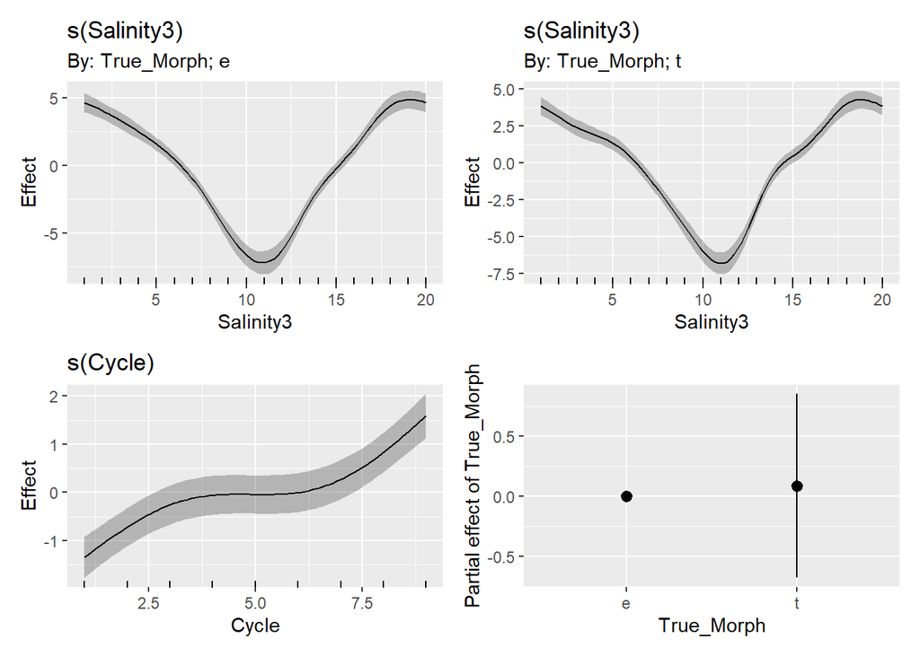

## Анализ силы прикрепления мидий в зависимости от стресса, связанного с понижением солености

Здесь еще ничего не причесывал, но можно оставить все как было в коде, который писали совместно.